# Deutsche Oper Berlin

Tosca

© 2013 // Marcus Lieberenz

[figure not shown]

Tosca

© 2013 // Marcus Lieberenz

[figure not shown]

Tosca

© 2013 // Marcus Lieberenz

[figure not shown]

Tosca

© 2013 // Marcus Lieberenz

[figure not shown]

Tosca

© 2013 // Bettina Stöß

[figure not shown]

Tosca

© 2013 // Bettina Stöß

[figure not shown]

Tosca

© 2013 // Bettina Stöß

[figure not shown]

Tosca

© 2013 // Bettina Stöß

[figure not shown]

Tosca

© 2013 // Bettina Stöß

[figure not shown]

Tosca

© 2013 // Bettina Stöß

[figure not shown]

Tosca

© 2009 // Bettina Stöß

[figure not shown]

Tosca

© 2013 // Marcus Lieberenz

[figure not shown]

Giacomo Puccini: Tosca

© Ruth Tromboukis

[figure not shown]

Ivan Inverardi singt „Te Deum“ aus TOSCA

© Ruth Tromboukis

[figure not shown]

Eine Einführung zu Puccinis „Tosca“

© Ruth Tromboukis

[figure not shown]

Sondra Radvanovsky singt „Vissi d'arte, vissi d'amore“ aus TOSCA

© Ruth Tromboukis

[figure not shown]

Fünf Cellisten spielen Tosca

© Ruth Tromboukis

[figure not shown]

50 Jahre „Tosca“ in der Inszenierung von Boleslav Barlog

© Ruth Tromboukis

[figure not shown]

Tosca

© 2013 // Marcus Lieberenz

[figure not shown]

Tosca

© 2013 // Marcus Lieberenz

[figure not shown]

Tosca

© 2013 // Marcus Lieberenz

[figure not shown]

Tosca

© 2013 // Marcus Lieberenz

[figure not shown]

Tosca

© 2013 // Marcus Lieberenz

[figure not shown]

Tosca

© 2013 // Marcus Lieberenz

[figure not shown]

Tosca

© 2013 // Marcus Lieberenz

[figure not shown]

Tosca

© 2013 // Bettina Stöß

[figure not shown]

Tosca

© 2013 // Bettina Stöß

[figure not shown]

Tosca

© 2013 // Bettina Stöß

[figure not shown]

Tosca

© 2013 // Bettina Stöß

[figure not shown]

Tosca

© 2013 // Bettina Stöß

[figure not shown]

Tosca

© 2013 // Bettina Stöß

[figure not shown]

Tosca

© 2009 // Bettina Stöß

[figure not shown]

Tosca

© 2013 // Marcus Lieberenz

[figure not shown]

© Ruth Tromboukis

[figure not shown]

© Ruth Tromboukis

[figure not shown]

© Ruth Tromboukis

[figure not shown]

© Ruth Tromboukis

[figure not shown]

© Ruth Tromboukis

[figure not shown]

© Ruth Tromboukis

[figure not shown]

Tosca

© 2013 // Marcus Lieberenz

[figure not shown]

Tosca

© 2013 // Marcus Lieberenz

[figure not shown]

Tosca

© 2013 // Marcus Lieberenz

[figure not shown]

Tosca

© 2013 // Marcus Lieberenz

# Tosca

Giacomo Puccini (1858 – 1924)

Informationen zum Werk

Melodramma in drei Akten  
Libretto von Giuseppe Giacosa und Luigi Illica  
nach dem Drama LA TOSCA von Victorien Sardou  
Uraufführung am 14. Januar 1900 in Rom  
Premiere an der Deutschen Oper Berlin am 13. April 1969  
empfohlen ab 13 Jahren

3 Stunden 15 Minuten / Zwei Pausen

In italienischer Sprache mit deutschen und englischen Übertiteln

Einführung: 45 Minuten vor Vorstellungsbeginn im Rang-Foyer rechts

Termine & Karten

- Familienvorstellung // Generationenvorstellung

  17:00

  Jan

  So

  C-Preise: € 100,00 / € 82,00 / € 58,00 / € 34,00 / € 24,00
- 12

  19:30

  Jan

  Do

  C-Preise: € 100,00 / € 82,00 / € 58,00 / € 34,00 / € 24,00
- 03

  19:30

  Mär

  Fr

  C-Preise: € 100,00 / € 82,00 / € 58,00 / € 34,00 / € 24,00
- Repertoire

  10

  19:30

  Mär

  Fr

  C-Preise: € 100,00 / € 82,00 / € 58,00 / € 34,00 / € 24,00
- 10

  17:00

  Apr

  Mo

  C-Preise: € 100,00 / € 82,00 / € 58,00 / € 34,00 / € 24,00
- Repertoire // Zum letzten Mal in dieser Spielzeit

  13

  19:30

  Apr

  Do

  C-Preise: € 100,00 / € 82,00 / € 58,00 / € 34,00 / € 24,00

Wir danken unseren Partnern

[figure not shown]

[figure not shown]

Der Kinderchor wird unterstützt von Engel & Völkers und Dobolino e. V.

zum Inhalt

Die literarische Vorlage zu Puccinis „Folteroper“ (Oskar Bie) lieferte Victorien Sardou (1831–1908) mit seinem erfolgreichen Theaterstück LA TOSCA, das 1887 in Paris mit Sarah Bernhardt in der Titelrolle uraufgeführt wurde. Nachdem Puccini 1889 das Stück auf einer Tournee in Mailand erlebt hatte, war er auf Anhieb begeistert von dem Stoff. Aber der TOSCA-Plan bleibt zunächst sechs Jahre liegen, bis Puccini, vermutlich angeregt durch eine weitere Aufführung des Sardou-Dramas in Florenz und durch Luigi Illicas Arbeit an einem TOSCA-Libretto für den Komponisten Alberto Franchetti (1860–1942), Interesse an dem Stoff findet. Nach einer „Verschwörung“ zwischen Puccini, Illica und Ricordi gelingt es dem Verleger, Franchetti zur Aufgabe seines TOSCA-Projektes zu bewegen und Puccini die Vertonungsrechte zu überlassen.  
Wie in allen Opern Puccinis zeigt auch TOSCA, wie menschliche Aufmerksamkeit und kulinarisches Vergnügen einander bedingen können, wenn die künstlerischen Intentionen des Komponisten zum Maßstab der Interpretation werden. Der Aufschrei wie die Resignation sind die wesentlichen Bedingungen der humanen Aufmerksamkeit Puccinis: Das Mitleid, das er komponierte, begnügt sich nicht mit abstrakten Gesten, sondern zielt auf Unruhe, auf Veränderung. Aus den »kleinen Dingen«, die Puccini mit modernem Understatement als seinen Gegenstand bezeichnete, werden „große“, sofern wir das nur wollen. Der Zusammenhang zwischen Puccinis direkt und indirekt vom Geist Zolas, Hauptmanns und Gorkis beeinflusster Stoffwahl und seiner Kompositionsweise zeigt ihn gleichermaßen als Nachfolger Verdis wie als Vertreter des Verismo. Bekanntlich war er ein großer Wagner-Verehrer, aber alles andere als ein Epigone. Vielmehr schuf er eine sehr persönliche Verbindung aus einigen Errungenschaften beider. Alle gewonnenen Verfeinerungen der Harmonie und alle Differenzierungen der Instrumentation verarbeitend, erlöste er dennoch die Stimme aus der orchestralen Verflechtung und gab ihr zugleich ein weitaus gebrocheneres, klangsensibleres Accompagnato im Orchester als der radikale Lakoniker Verdi. Dafür steht auch die ästhetische Thematik der TOSCA. Der musikalische Gestus ist ebenso brutal wie zärtlich, intelligent wie sentimental, präzise wie träumerisch. Puccini möchte unbedingt Lebenswahrheit, Genauigkeit auch des musikalischen Details, soziale Aufmerksamkeit, den poetischen Klang des scheinbar Alltäglichen, das Heroische mit Kalkül, den Kontrast zwischen engagierter Leidenschaft und kühler Distanz.  
Der Polizeichef Scarpia, die Sängerin Floria Tosca und der Maler Cavaradossi beanspruchen Freiheit in jeder persönlichen Variante: als dynamisch-subjektiven Machtanspruch (Scarpia), als auf Veränderung zielendes rebellisches Ethos (Cavaradossi), als private, schlichte und zugleich grenzenlose Liebe (Tosca).  
In einer Zeit epochaler Umwälzungen gewinnen solche Haltungen exemplarische Sinnfälligkeit. Je nachdem, wie wir uns und Puccini in dieser Zeit begreifen, bleibt TOSCA eine Schauerromanze oder gerät zum Menetekel des Themas „Freiheit“. Jedenfalls bezahlt jeder der konträren Partner diese Dreiecksgeschichte mit dem Tod. Ihr Sterben nimmt keine Erlösungsgloriole für sich in Anspruch, sondern ist bitter, entsetzlich, definitiv.  
Götz Friedrichs 1987 vorgenommene Neueinstudierung von Boleslaw Barlogs geradliniger und auf szenische Konkretheit bedachter Inszenierung aus dem Jahr 1969 nimmt die Intentionen Puccinis beim Wort – die gegenseitige Bedingtheit von menschlicher Aufmerksamkeit und kulinarischem Vergnügen wird von der Musik inspiriert zum Ausgangspunkt auch der szenischen Interpretation.

## Unsere Artikel zum Thema

[figure not shown]

Dr. Takt über Giacomo Puccinis „Tosca“ / Akt I, vierter Takt vor Ziffer 5

[mehr erfahren](https://deutscheoperberlin.de/de_DE/dr-takt-ueber-tosca)

[figure not shown]

Schusswaffen

[mehr erfahren](https://deutscheoperberlin.de/de_DE/das-requisit-2)

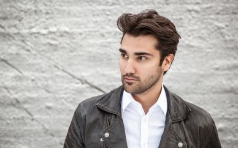

Acht Fragen an ... Jonathan Tetelman

[mehr erfahren](https://deutscheoperberlin.de/de_DE/fragen-an-jonathan-tetelman)

## Unsere Empfehlungen

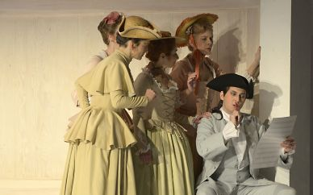

Manon Lescaut

[mehr erfahren](https://deutscheoperberlin.de/de_DE/production/manon-lescaut.1319716)

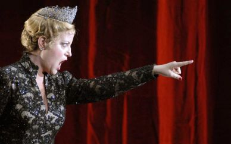

Turandot

[mehr erfahren](https://deutscheoperberlin.de/de_DE/production/turandot.1319723)

[figure not shown]

La bohème

[mehr erfahren](https://deutscheoperberlin.de/de_DE/production/la-boheme.1319715)

[figure not shown]

Tosca

[mehr erfahren](https://deutscheoperberlin.de/de_DE/production/tosca.1337099)